# Tarea-Hflights-132035

Daniel Alberto Santiago Reyes

10/26/2018

[figure not shown]

# Ejercicio-tarea práctico

## Ejercicio 1

### ¿Qué tipo de información tiene?

El dataset de hflights tiene la información de los vuelos entrantes y salientes de los aeropuertos de Houston Texas (HOU y IAH).

### ¿Cuántas observaciones tiene el dataset?

```r
NROW(hflights)
```

```
## [1] 227496
```

El dataset tiene 227,496 observaciones.

### ¿Cuántas columnas?

```r
NCOL(hflights)
```

```
## [1] 21
```

El dataset tiene 21 columnas.

### ¿Cuáles son los nombres de las variables?

Los nombres de las variables los obtenemos con la función names().

```r
names(hflights)
```

```
##  [1] "Year"              "Month"             "DayofMonth"
##  [4] "DayOfWeek"         "DepTime"           "ArrTime"
##  [7] "UniqueCarrier"     "FlightNum"         "TailNum"
## [10] "ActualElapsedTime" "AirTime"           "ArrDelay"
## [13] "DepDelay"          "Origin"            "Dest"
## [16] "Distance"          "TaxiIn"            "TaxiOut"
## [19] "Cancelled"         "CancellationCode"  "Diverted"
```

### ¿Qué tipo de variable son?

```
##              Year             Month        DayofMonth         DayOfWeek
##         "integer"         "integer"         "integer"         "integer"
##           DepTime           ArrTime     UniqueCarrier         FlightNum
##         "integer"         "integer"       "character"         "integer"
##           TailNum ActualElapsedTime           AirTime          ArrDelay
##       "character"         "integer"         "integer"         "integer"
##          DepDelay            Origin              Dest          Distance
##         "integer"       "character"       "character"         "integer"
##            TaxiIn           TaxiOut         Cancelled  CancellationCode
##         "integer"         "integer"         "integer"       "character"
##          Diverted
##         "integer"
```

### ¿Despliega un pequeño resumen de las variables numéricas (media, meadiana, desviación, etc).

```
##                   vars      n   mean     sd median trimmed    mad min  max
## ActualElapsedTime    1 223874 129.32  59.29    128  124.99  66.72  34  575
## AirTime              2 223874 108.14  56.56    107  103.68  62.27  11  549
## ArrDelay             3 223874   7.09  30.71      0    1.85  13.34 -70  978
## DepDelay             4 224591   9.44  28.80      0    3.37   5.93 -33  981
## Distance             5 227496 787.78 453.68    809  759.55 563.39  79 3904
## TaxiIn               6 224430   6.10   3.96      5    5.47   1.48   1  165
## TaxiOut              7 224549  15.09   7.74     14   14.12   5.93   1  163
##                   range skew kurtosis   se
## ActualElapsedTime   541 0.87     2.22 0.13
## AirTime             538 0.97     2.84 0.12
## ArrDelay           1048 5.04    55.57 0.06
## DepDelay           1014 5.97    71.90 0.06
## Distance           3825 0.91     3.32 0.95
## TaxiIn              164 5.58    86.04 0.01
## TaxiOut             162 3.26    26.99 0.02
```

### Omite las variables tipo “NA” en tu análisis.

```r
hfsinna <- na.omit(hflights)
```

## Ejercicio 2

Codificar correctamente cada tipo de variable por su tipo (numéricas, categóricas o strings), especialmente atención en fechas y variables categóricas (como UniqueCarrier y DayOfWeek).

```r
str(hfsinna)
```

```
## 'data.frame':    223874 obs. of  21 variables:
##  $ Year             : int  2011 2011 2011 2011 2011 2011 2011 2011 2011 2011 ...
##  $ Month            : int  1 1 1 1 1 1 1 1 1 1 ...
##  $ DayofMonth       : int  1 2 3 4 5 6 7 8 9 10 ...
##  $ DayOfWeek        : int  6 7 1 2 3 4 5 6 7 1 ...
##  $ DepTime          : int  1400 1401 1352 1403 1405 1359 1359 1355 1443 1443 ...
##  $ ArrTime          : int  1500 1501 1502 1513 1507 1503 1509 1454 1554 1553 ...
##  $ UniqueCarrier    : chr  "AA" "AA" "AA" "AA" ...
##  $ FlightNum        : int  428 428 428 428 428 428 428 428 428 428 ...
##  $ TailNum          : chr  "N576AA" "N557AA" "N541AA" "N403AA" ...
##  $ ActualElapsedTime: int  60 60 70 70 62 64 70 59 71 70 ...
##  $ AirTime          : int  40 45 48 39 44 45 43 40 41 45 ...
##  $ ArrDelay         : int  -10 -9 -8 3 -3 -7 -1 -16 44 43 ...
##  $ DepDelay         : int  0 1 -8 3 5 -1 -1 -5 43 43 ...
##  $ Origin           : chr  "IAH" "IAH" "IAH" "IAH" ...
##  $ Dest             : chr  "DFW" "DFW" "DFW" "DFW" ...
##  $ Distance         : int  224 224 224 224 224 224 224 224 224 224 ...
##  $ TaxiIn           : int  7 6 5 9 9 6 12 7 8 6 ...
##  $ TaxiOut          : int  13 9 17 22 9 13 15 12 22 19 ...
##  $ Cancelled        : int  0 0 0 0 0 0 0 0 0 0 ...
##  $ CancellationCode : chr  "" "" "" "" ...
##  $ Diverted         : int  0 0 0 0 0 0 0 0 0 0 ...
##  - attr(*, "na.action")= 'omit' Named int  195 211 253 284 324 336 348 416 425 535 ...
##   ..- attr(*, "names")= chr  "33074" "35264" "39463" "50174" ...
```

## Ejercicio 3

| Nombre.columna | Descripción | Posibles.valores | Tipo.de.dato | Justificación |
| --- | --- | --- | --- | --- |
| Year | Año | 2011 | Categóricas: Numérico | El año se puede seleccionar en este dataset el único año es 2011, pero si se agregaran más dartos se converitiría en una opción. |
| Month | Mes | (1-12) | Categóricas: Numérico | En el dataset se representa el número con el mes, es decir el 1 es Enereo; 2 es Febrero; y así sucesibamente. |
| DayofMonth | Día | (1-31) | Categóricas: Numérico | En el dataset se indica el día del mes y el limite es 31 ya que es el número máximo de días que puede tener un mes. |
| DayOfWeek | Día de la semana en que Salío el avión. | (1-7) | Categóricas: Numérico | Los valores van del 1 al 7 para idicar 1 -Lunes |
| DepTime | Tiempo de salida del avión (en tiempo local, hhmm) | (1 - 2400) | Categóricas: Numérico | Puede tomar varios valores desde 1 al 2400 |
| ArrTime | Tiempo de llegada del avión (en tiempo local, hhmm) | (1 - 2400) | Categóricas: Numérico | Puede tomar varios valores desde 1 al 2400 |
| UniqueCarrier | Abreviación única de aerolineas | AA “AS” “B6” “CO” “DL” “EV” “F9” “FL” “MQ” “OO” “UA” “US” “WN” “XE” “YV” | Categóricas: Texto | Es un catálago finito de aerolineas |
| FlightNum | Número de vuelo | 25, 8, 2590, 35, 1 | Categóricas: Numérico | El número de vuelo se puede repeticr constantemente |
| TailNum | Número de control para identificar el avion | “N576AA”N557AA" “N541AA” “N403AA” “N492AA” | Categóricas: Texto | Pude ser cualquier número asigndo ocmo identificador del avión e incluyen letras. |
| ActualElapsedTime | Tiempo transcurrido | 60, 70, 80 | Númericas | puede tomar varios valores en terminos de minutos |
| AirTime | Tiempo de vuelo | 11, 58,107 | Númericas | puede tomar varios valores en terminos de minutos |
| ArrDelay | Retraso de llegada | 11,-70-8. | Númericas | puede tomar varios valores en terminos de minutos |
| DepDelay | Retraso de salida | 9, -3, -33 | Númericas | puede tomar varios valores en terminos de minutos |
| Origin | Origen | “HOU” “IAH” | Categóricas: Texto | Selección del origen |
| Dest | Destino | “AEX” “BKG”“SAV” | Categóricas: Texto | Selección del destino |
| Distance | Distancia del vuelo en millas | 79, 46, 180 | Númericas | Puede tomar varios valores de distancia |
| TaxiIn | Tiempo llrgada de taxi | (1 - 165) | Númericas | Puede tomar varios valores expresado en minutos |
| TaxiOut | Tiempo de llegada del avión (en tiempo local, hhmm) | (1 - 163) | Númericas | Puede tomar varios valores expresado en minutos |
| Cancelled | Cancelado | 1,0 | Categóricas: Numérico | 1 = si, 2=no |
| CancellationCode | Código de cancelación | A,B,C,D | Categóricas: Texto | A=aerolinea, B=Clima, C=Sistema nacional de vuelo, D=Seguridad |
| Diverted | Desviado | 1,0 | Categóricas: Numérico | 1 = si, 2=no |

## Ejercicio 4

Imaginen que quieren analizar si hay días en donde preferirían no viajar y ciertos carriers (aerolíneas) que quisieran evitar usar.

### Números de Vuelo vs Días de la semana

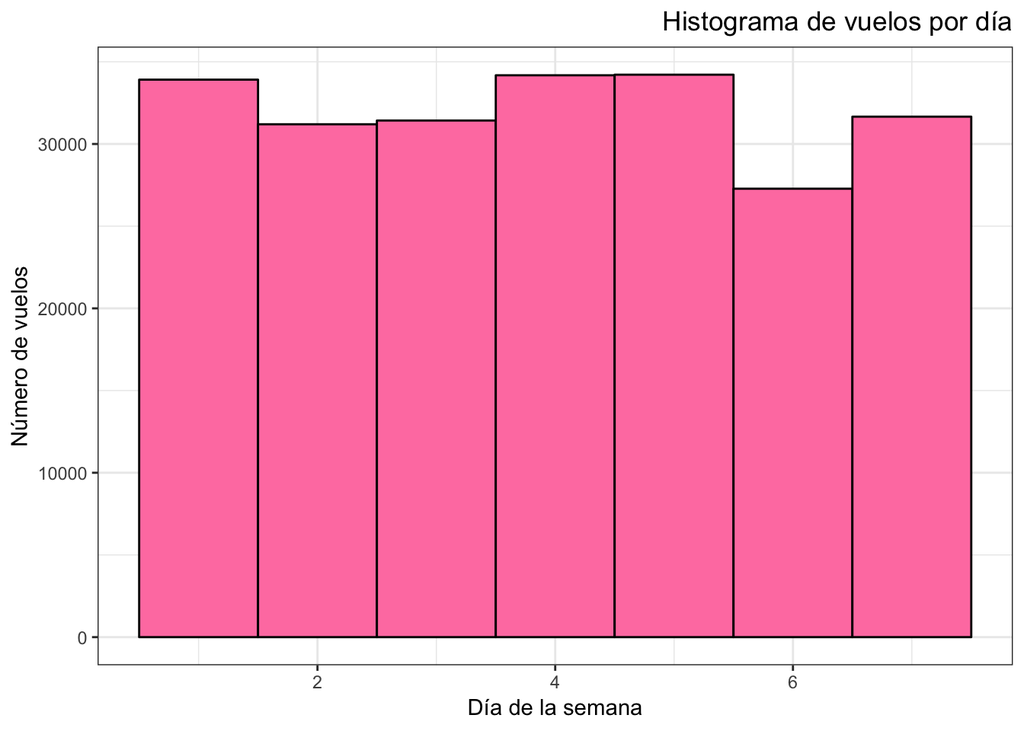

Con este histograma podemos ver que los días con más vuelos son:

- Lunes (1)
- Jueves (4)
- Viernes (5)

### Número de vuelos por aerolinea segmentados en días de la semana

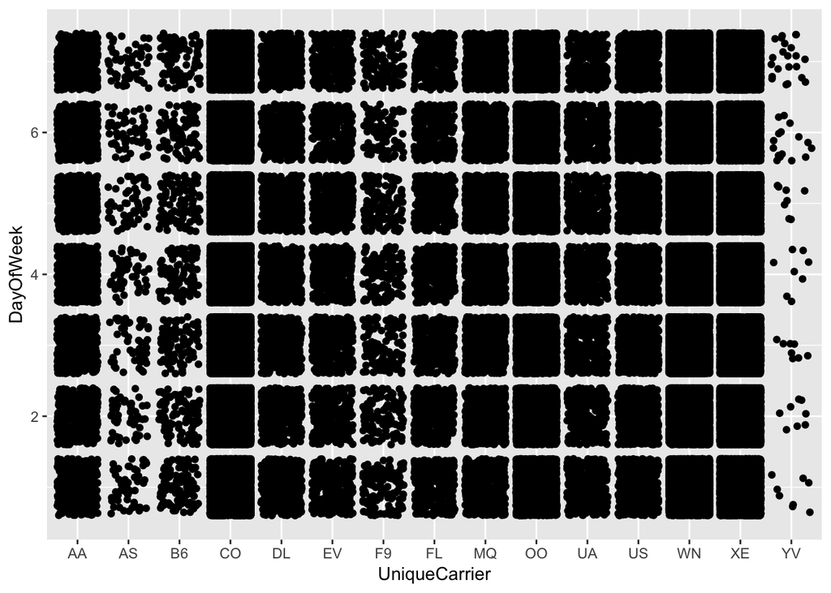

### Retrasos de Llegada por Aerolinea

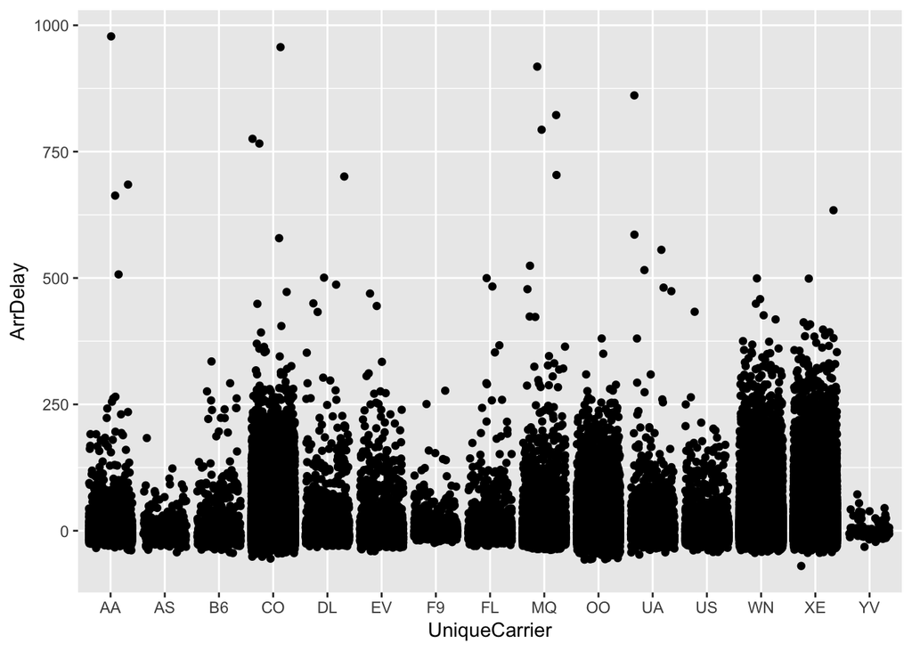

### Retrasos de Salida por Aerolinea

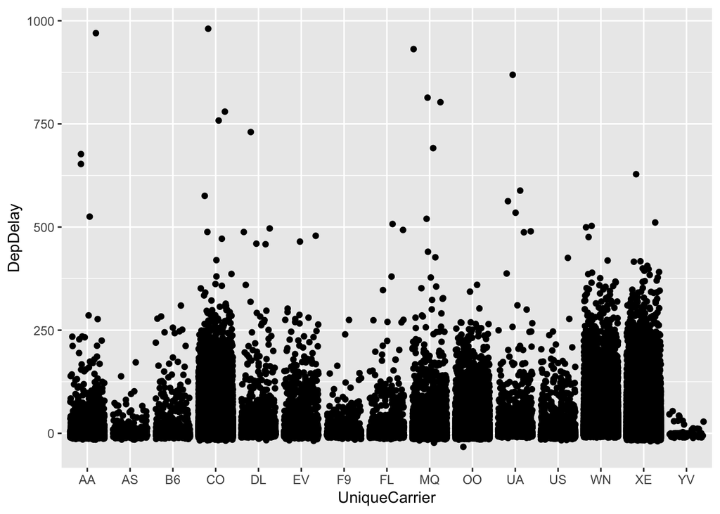

Con las tres gráficas anteriores podemos ver que las aerolineas con mas vuelos (CO,OO, WN, XE) durante toda la semana, también son las aerolineas con mas retrasos reportados.

Adicionalmente, hay una relación importante entre las variables de retraso de llegada y retraso de salida.

## Ejercicio 5

Haz una boxplot que nos permita ver la distribución del retraso en tiempo de partida (Depdelay) para cada carrier (UniqueCarrier).

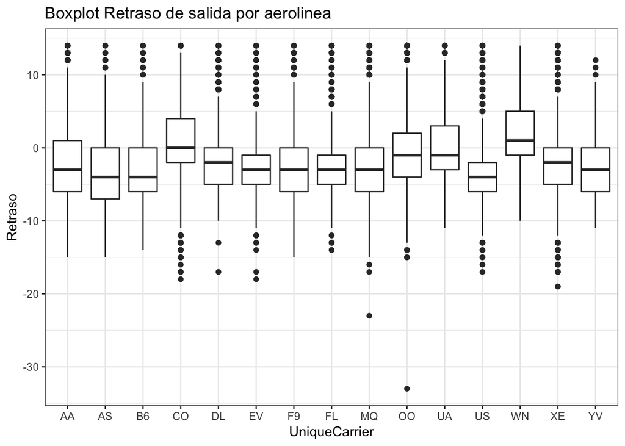

## Ejercicio 6

Haz una gráfica de barras de Arrival Delays por día de la semana. ¿En qué días se dan los mayores retrasos?

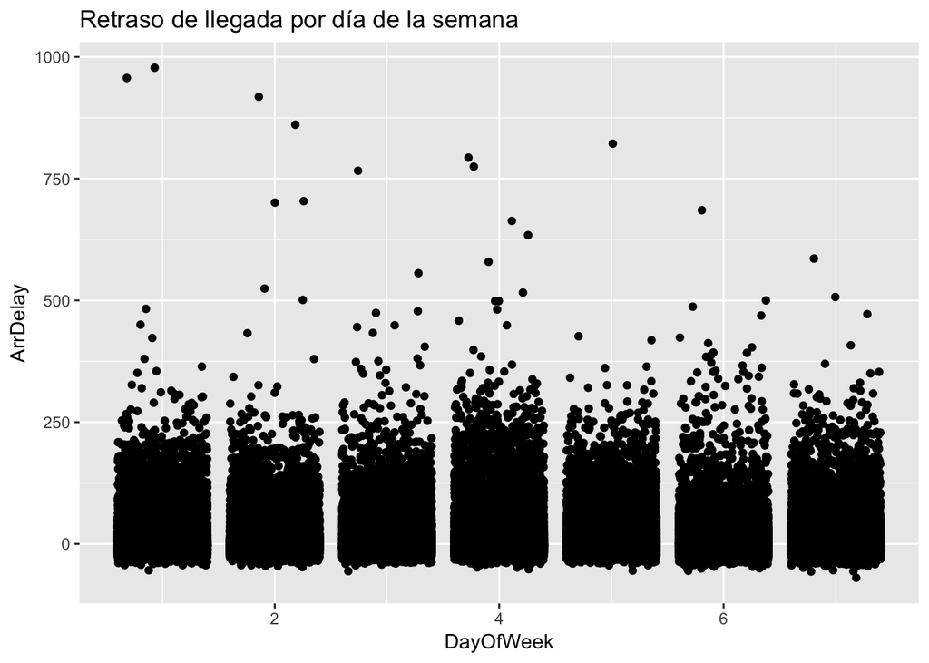

Aparentemente el jueves es el día con mayores retrasos, y es uno de los días con más intensidad operativa.

## Ejercicio 7

Haz una gráfica que nos permita entender cuántos son los retrasos por día de la semana para cada carrier . ¿Existen días en los que se den más retrasos?

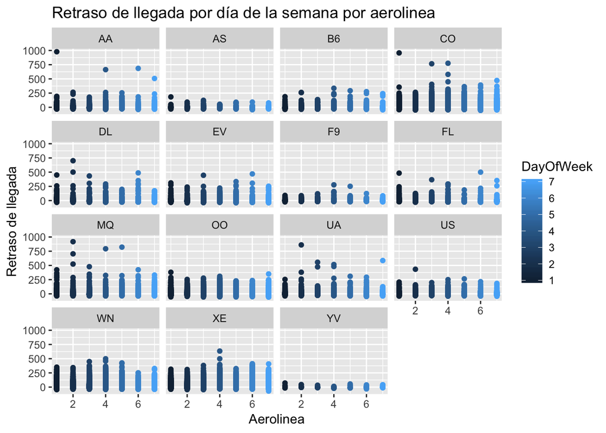

[figure not shown]

## Ejercicio 8

¿Crees que exista una relación entre un retraso en el tiempo de partida (Depdelay) y un retraso en el tiempo de llegada (ArrDelay)? Haz un diagrama de dispersión de ambas variables para confirmarlo o negar este hecho. Finalmente confirma o rechaza con una prueba de hipótesis que existe una relación lineal entre ambas variables.

[figure not shown]

```r
cor.test(retrasos$ArrDelay, retrasos$DepDelay, method = "pearson", use = "complete.obs")
```

```
##
##  Pearson's product-moment correlation
##
## data:  retrasos$ArrDelay and retrasos$DepDelay
## t = 1189.8, df = 223870, p-value < 2.2e-16
## alternative hypothesis: true correlation is not equal to 0
## 95 percent confidence interval:
##  0.9286503 0.9297816
## sample estimates:
##       cor
## 0.9292181
```

## Ejercicio 12

Be happy!

[figure not shown]